# Fitness Data Prediction

Sammie Bae

December 22, 2015

# Background:

Using devices such as Jawbone Up, Nike FuelBand, and Fitbit it is now possible to collect a large amount of data about personal activity relatively inexpensively. These type of devices are part of the quantified self movement - a group of enthusiasts who take measurements about themselves regularly to improve their health, to find patterns in their behavior, or because they are tech geeks. One thing that people regularly do is quantify how much of a particular activity they do, but they rarely quantify how well they do it. In this project, data from belt accelerometers to predict what excercise 6 participants are doing between forearm, arm, and dumbell of 6 participants. They were asked to perform barbell lifts correctly and incorrectly in 5 different ways.

# Goal

The goal of the project is to predict the manner in which they did the exercise. This is the “classe” variable in the training set. These exercise vary accordingly: “exactly according to the specification (Class A), throwing the elbows to the front (Class B), lifting the dumbbell only halfway (Class C), lowering the dumbbell only halfway (Class D) and throwing the hips to the front (Class E). Class A corresponds to the specified execution of the exercise, while the other 4 classes correspond to common mistakes.” The model should predict accurately on 20 sample different test cases.

# Setup

Loading the data and setup:

```r
library(knitr)
library(caret)
library(randomForest)
```

```r
library(rpart)
library(rpart.plot)
library(rattle)
#set the working directory
setwd("C:/Users/Sam.E/Desktop/datasciencecoursera/Practical Machine Learning/Course Write-up")
#Data Source:
if(!file.exists("pml-training.csv")){
  download.file("https://d396qusza40orc.cloudfront.net/predmachlearn/pml-training.csv", destfile = "pml-training.csv")
}
if(!file.exists("pml-testing.csv")){
  download.file("https://d396qusza40orc.cloudfront.net/predmachlearn/pml-testing.csv", destfile = "pml-testing.csv")
}
training <-read.csv("pml-training.csv", na.strings=c("NA",""),stringsAsFactors = FALSE)
testing <-read.csv("pml-testing.csv", na.strings=c("NA",""),stringsAsFactors = FALSE)
dim(training);dim(testing)
```

```
## [1] 19622   160
```

```
## [1]  20 160
```

# Data Preprocessing & Clean-up

```r
#undefined data to N/A
  undefinedToNA <- sapply(training, function(x) x=="#DIV/0!")
  training[undefinedToNA] <- NA
```

To build a machine learning model, numeric values are preffered, binary values such as Yes or No should be changed to 1 or 0

```r
#convert yes/no into 1/0
  #testing
    testing$new_window = 1*(testing$new_window=="yes")
    testing$new_window <- as.factor(testing$new_window)
  #training
    training$new_window = 1*(training$new_window=="yes")
    training$new_window <- as.factor(training$new_window)
    training$classe <- factor(training$classe)
```

```r
#removes first column with ID and username
training<- training[,-2]
testing <- testing[,-2]
#remove N/A value columns
training <- training[, unlist(lapply(training, function(x) !any(is.na(x))))]
testing <- testing[, unlist(lapply(testing, function(x) !any(is.na(x))))]

dim(training);dim(testing)
```

```
## [1] 19622    59
```

```
## [1] 20 59
```

# Data Partitioning

For this partitioning, training and testing data set are 60% and 40% respectively

```r
inTrain<-createDataPartition(y=training$classe, p=0.6, list=FALSE)
dataTraining<-training[inTrain, ]
dataTesting <-training[-inTrain, ]
training<- training[, sapply(training, is.numeric)]
testing <- testing[, sapply(testing, is.numeric)]
```

# Model Building

## Method 1: Random Forrests

### Training the model with Random Forrests

Random forest trees are one of the best prediction model in machine learning. This dataset will first be modelled with trees:

```r
trainingModelRF <- train(classe ~ .,trControl=trainControl(method = "cv", number = 5),data=dataTraining, method="rf")
print(trainingModelRF)
```

```
## Random Forest
##
## 11776 samples
##    58 predictor
##     5 classes: 'A', 'B', 'C', 'D', 'E'
##
## No pre-processing
## Resampling: Cross-Validated (5 fold)
## Summary of sample sizes: 9422, 9420, 9420, 9421, 9421
## Resampling results across tuning parameters:
##
##   mtry  Accuracy   Kappa      Accuracy SD   Kappa SD
##    2    0.9960938  0.9950591  0.0019318045  0.0024435519
##   39    0.9997453  0.9996778  0.0002325128  0.0002940822
##   76    0.9995754  0.9994630  0.0003001303  0.0003795999
##
## Accuracy was used to select the optimal model using  the largest value.
## The final value used for the model was mtry = 39.
```

```r
#fancyRpartPlot(trainingModelRF$finalModel)
```

### Prediction model with Random Forrests

```r
predictionRF<-predict(trainingModelRF, dataTesting)
confusionMatrix(predictionRF, dataTesting$classe)
```

```
## Confusion Matrix and Statistics
##
##           Reference
## Prediction    A    B    C    D    E
##          A 2232    0    0    0    0
##          B    0 1518    0    0    0
##          C    0    0 1368    0    0
##          D    0    0    0 1286    0
##          E    0    0    0    0 1442
##
## Overall Statistics
##
##                Accuracy : 1
##                  95% CI : (0.9995, 1)
##     No Information Rate : 0.2845
##     P-Value [Acc > NIR] : < 2.2e-16
##
##                   Kappa : 1
##  Mcnemar's Test P-Value : NA
##
## Statistics by Class:
##
##                      Class: A Class: B Class: C Class: D Class: E
## Sensitivity            1.0000   1.0000   1.0000   1.0000   1.0000
## Specificity            1.0000   1.0000   1.0000   1.0000   1.0000
## Pos Pred Value         1.0000   1.0000   1.0000   1.0000   1.0000
## Neg Pred Value         1.0000   1.0000   1.0000   1.0000   1.0000
## Prevalence             0.2845   0.1935   0.1744   0.1639   0.1838
## Detection Rate         0.2845   0.1935   0.1744   0.1639   0.1838
## Detection Prevalence   0.2845   0.1935   0.1744   0.1639   0.1838
## Balanced Accuracy      1.0000   1.0000   1.0000   1.0000   1.0000
```

### Plotting Random Forrests Model

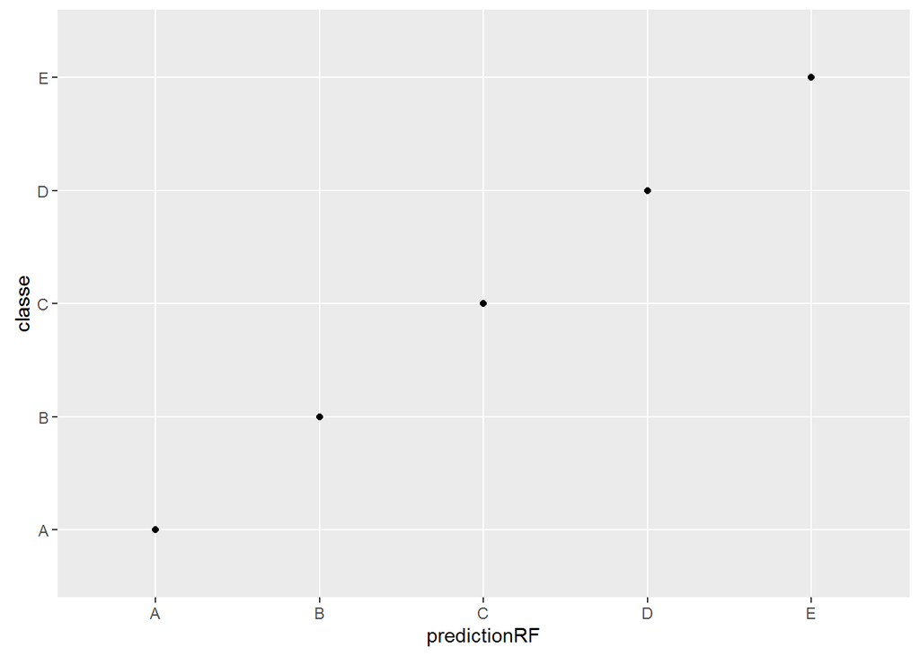

```r
qplot(predictionRF,classe,data=dataTesting)
```

###Accuracy of Random Forrests

```r
accuracy <- postResample(predictionRF, dataTesting$classe)
model_accuracy <- accuracy[[1]]*100
model_accuracy
```

```
## [1] 100
```